# Time Series HW 12

#### 2a. Using the maxtemp dataset granted by loading fpp2, there are maximum annual temperature data in Celsius. For more information, use help(maxtemp). To see what you’re looking at, execute the command in ‘Examples’ in the help document.

```r
head(maxtemp)
```

```
## Time Series:
## Start = 1971
## End = 1976
## Frequency = 1
## [1] 34.6 39.3 40.5 36.8 39.7 40.5
```

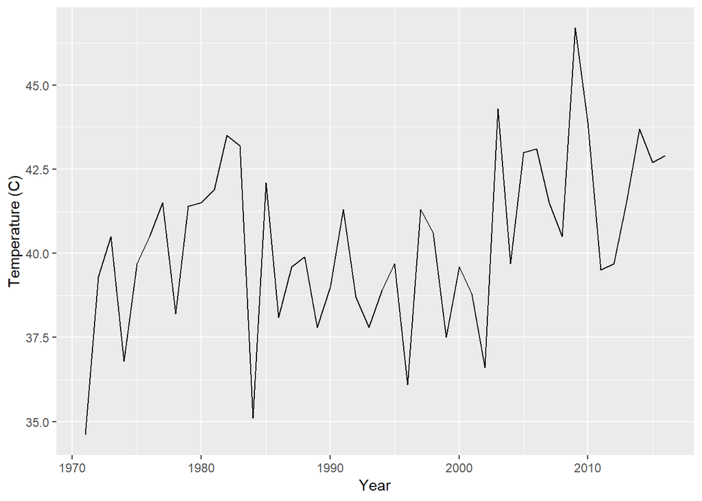

```r
autoplot(maxtemp, xlab="Year", ylab="Temperature (C)")
```

#### 2b. We are only concerned with information after 1990. Please eliminate unwanted information or subset information we don’t care about.

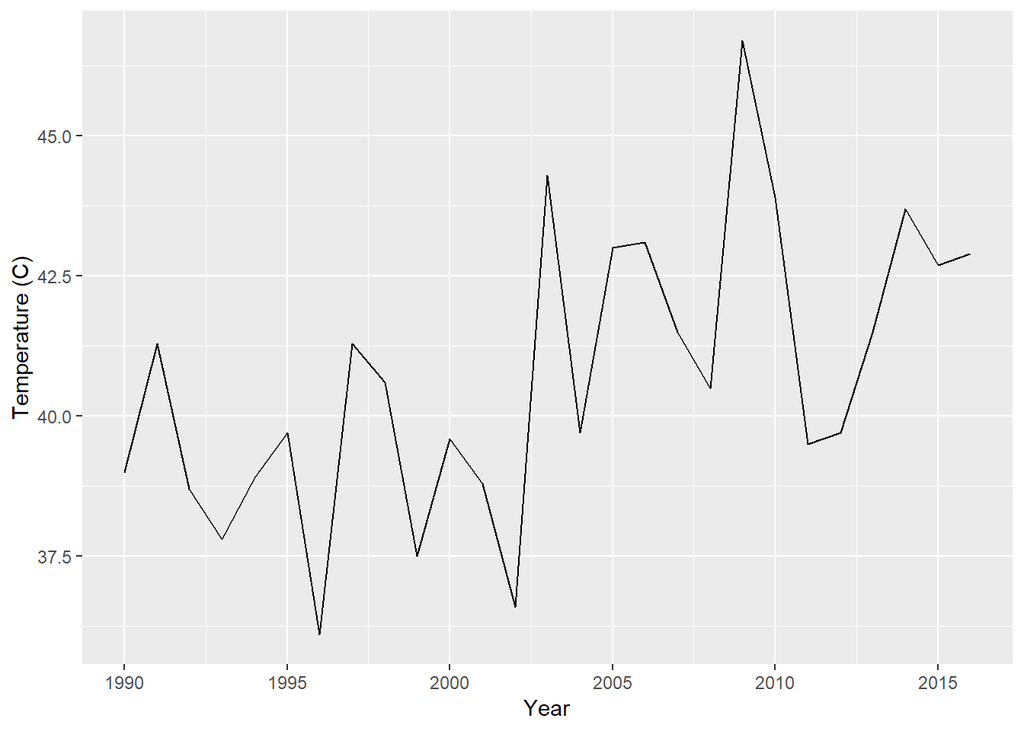

```r
tsTemp <- window(maxtemp, start=1990)                   # limit data seen, start=1990
autoplot(tsTemp, xlab="Year", ylab="Temperature (C)")
```

#### 2c. Utilize SES to predict the next five years of maximum temperatures in Melbourne. Plot this information, including the prior information and the forecast. Add the predicted value line across 1990-present as a separate line, preferably blue. So, to review, you should have your fit, the predicted value line overlaying it, and a forecast through 2021, all on one axis. Find the AICc and BIC of this fitted model. You will use that information later.

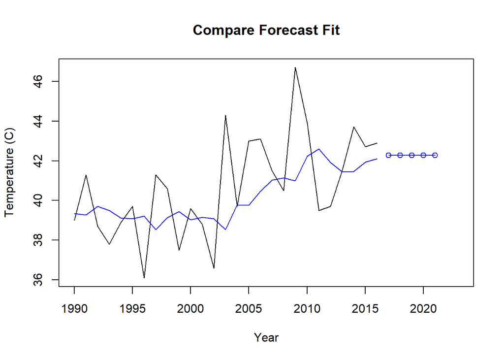

```r
fit.ses <- ses(tsTemp, h=5,initial="optimal")
plot(tsTemp,main="Compare Forecast Fit",xlab="Year", ylab="Temperature (C)",xlim=c(1990,2023)) # plot & extend x-axis
lines(fitted(fit.ses), col="blue")         # add fit
lines(fit.ses$mean, col="blue",type="o")   # add predicted fit
```

#### 2d. Now use a damped Holt’s linear trend to also predict out five years. Make sure initial=“optimal.” As above, create a similar plot to 1C, but use the Holt fit instead.

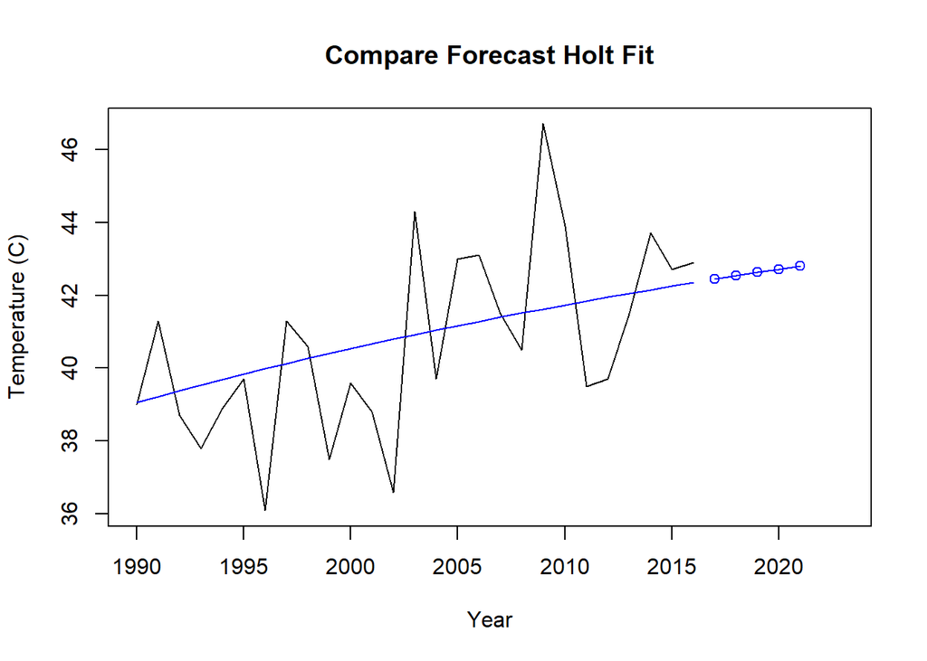

```r
fit.holt <- holt(tsTemp,damped=TRUE, h=5, initial = "optimal")
plot(tsTemp,main="Compare Forecast Holt Fit",xlab="Year", ylab="Temperature (C)",xlim=c(1990,2023)) # plot & extend x-axis
lines(fitted(fit.holt), col="blue")         # add fit
lines(fit.holt$mean, col="blue",type="o")   # add predicted fit
```

#### 2e. Compare the AICc and BIC of the ses() and holt() models. Which model is better here?

```r
summary(fit.ses)
```

```
##
## Forecast method: Simple exponential smoothing
##
## Model Information:
## Simple exponential smoothing
##
## Call:
##  ses(y = tsTemp, h = 5, initial = "optimal")
##
##   Smoothing parameters:
##     alpha = 0.2164
##
##   Initial states:
##     l = 39.345
##
##   sigma:  2.4135
##
##      AIC     AICc      BIC
## 140.4868 141.5302 144.3743
##
## Error measures:
##                     ME     RMSE      MAE      MPE     MAPE      MASE
## Training set 0.5018493 2.322345 1.776513 0.947593 4.301593 0.7390293
##                     ACF1
## Training set -0.09460844
##
## Forecasts:
##      Point Forecast    Lo 80    Hi 80    Lo 95    Hi 95
## 2017       42.27727 39.18431 45.37024 37.54700 47.00755
## 2018       42.27727 39.11272 45.44183 37.43750 47.11704
## 2019       42.27727 39.04271 45.51184 37.33043 47.22411
## 2020       42.27727 38.97418 45.58036 37.22563 47.32891
## 2021       42.27727 38.90705 45.64750 37.12296 47.43158
```

```r
summary(fit.holt)
```

```
##
## Forecast method: Damped Holt's method
##
## Model Information:
## Damped Holt's method
##
## Call:
##  holt(y = tsTemp, h = 5, damped = TRUE, initial = "optimal")
##
##   Smoothing parameters:
##     alpha = 1e-04
##     beta  = 1e-04
##     phi   = 0.98
##
##   Initial states:
##     l = 38.8993
##     b = 0.1678
##
##   sigma:  2.3409
##
##      AIC     AICc      BIC
## 141.3865 145.5865 149.1615
##
## Error measures:
##                      ME     RMSE      MAE       MPE     MAPE      MASE
## Training set -0.1536912 2.113041 1.674417 -0.667571 4.132949 0.6965577
##                     ACF1
## Training set -0.01925071
##
## Forecasts:
##      Point Forecast    Lo 80    Hi 80    Lo 95    Hi 95
## 2017       42.43990 39.43995 45.43986 37.85187 47.02794
## 2018       42.53313 39.53317 45.53308 37.94509 47.12116
## 2019       42.62449 39.62453 45.62444 38.03645 47.21252
## 2020       42.71402 39.71406 45.71397 38.12598 47.30205
## 2021       42.80176 39.80181 45.80171 38.21373 47.38979
```

##### SES AICC = 141.53, HOLT AICC = 145.59

##### SES BIC = 144.37, HOLT BIC = 149.16

##### The ses model is better based on the lower values for AICC and BIC.

#### 2f. Calculate and compare the ASE from the ses() and holt() models. Which one performs better with respect to this metric?

```r
ASE.ses=(sum((fit.ses$fitted-tsTemp)^2))/length(tsTemp)   # calc ASE for ses fit
ASE.ses
```

```
## [1] 5.393285
```

```r
ASE.holt=(sum((fit.holt$fitted-tsTemp)^2))/length(tsTemp) # calc ASE for holt fit
ASE.holt
```

```
## [1] 4.464942
```

##### SES ASE = 5.39, SES HOLT = 4.46. The holt model performs better based on lower ASE.

#### 3a. Utilize the dygraphs library. Read in both Unit12TimeSeries_Ollivander and _Gregorovitch.csv as two different data frames. They do not have headers, so make sure you account for that. This is a time series of Wands sold over years.

```r
ollivanderDF <- read.csv(".\\InputFiles\\Unit12TimeSeries_Ollivander.csv",header=TRUE,sep=",",encoding = "UTF-8")
names(ollivanderDF) <- c("Year","Wands") # rename table columns

gregorovitchDF <- read.csv(".\\InputFiles\\Unit12TimeSeries_Gregorovitch.csv",header=TRUE,sep=",",encoding = "UTF-8")
names(gregorovitchDF) <- c("Year","Wands") # rename table columns
```

#### 3b. You don’t have your information in the proper format! In both data sets, you’ll need to first convert the date-like variable to an actual Date class.

```r
ollivanderDF$Year <- as.Date(ollivanderDF$Year,"%m/%d/%Y")        # convert/format date columns for TS
gregorovitchDF$Year <- as.Date(gregorovitchDF$Year,"%m/%d/%Y")    # convert/format date columns for TS
```

#### 3c. Use the library xts and the xts() function in it to make each data frame an xts object (effectively, a time series). You’ll want to order.by the Date variable.

```r
ollivanderTS <- xts(ollivanderDF[,-1], order.by = as.Date(ollivanderDF[,1]))        # convert DF to TS
gregorovitchTS <- xts(gregorovitchDF[,-1], order.by = as.Date(gregorovitchDF[,1]))  # convert DF to TS
```

#### 3d. Bind the two xts objects together and create a dygraph from it.

```r
wands <- cbind(ollivanderTS, gregorovitchTS)                      # create 2 columns of time series
colnames(wands) <- c("Ollivander","Gregorovitch")                 # rename columns

dygraph(wands,main="Wand Sales",xlab="Year",ylab="Wand Qty") %>%  # create dygraph and label axes & title
  dyOptions(colors = RColorBrewer::brewer.pal(3,"Set1")) %>%      # change default colors
  dyOptions(stackedGraph = TRUE) %>%                              # stack data
  dyRangeSelector(height = 70) %>%                                # add range selector and enlarge
  dyHighlight(highlightSeriesOpts = list(strokeWidth = 3)) %>%    # enable interactie highlighting
  dyShading(from="1995-1-1", to="1999-1-1",color="yellow")        # shade 1995-1999
```

[interactive chart not shown]